# Predicting Weather

### Can we predict the “Actual Maximum Temperature” for January 14th, 2019?

```r
# load libraries and data set
library(tidyverse)
library(car)
library(DT)
library(pander)
weather <- read_csv("../Data/PredictingWeather.csv")
```

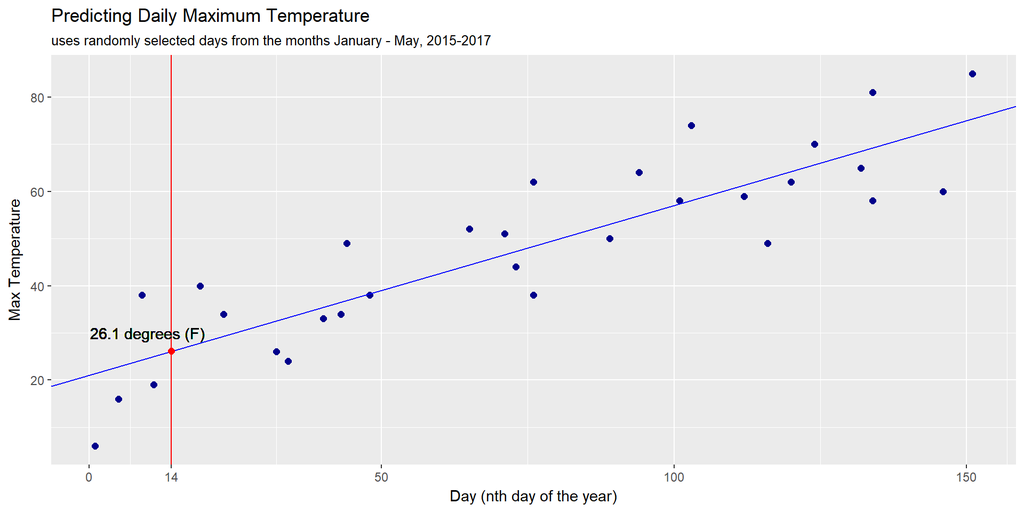

```r
weather %>%
  ggplot(aes(x = day, y = max_temp)) +
  geom_point(color = "darkblue", size = 2) +
  geom_abline(intercept = 21.03, slope = 0.36, color = "blue") +
  geom_vline(xintercept = 14, color = "red") +
  geom_point(aes(x = 14, y = 26.11), color = "red", size = 2) +
  geom_text(aes(x = 10, y = 30, label = "26.1 degrees (F)")) +
  scale_x_continuous(breaks = c(0, 14, 50, 100, 150)) +
  labs(title = "Predicting Daily Maximum Temperature",
       subtitle = "uses randomly selected days from the months January - May, 2015-2017",
       x = "Day (nth day of the year)",
       y = "Max Temperature")
```

This graph shows the regression line that is fitted to the data. On the 14th day of the year, the regression predicts an Actual Maximum Temperature of **26.1 degrees Fahrenheit**. The actual high temperature for the day was **28 degrees**. The regression turned out to be fairly accurate in this case. It has an R-squared value of 0.77, which is a decent fit.

#### The Data

The data collected was taken from BYUI’s weather database at http://web.byui.edu/Weather/. The sample consists of 30 observations – 2 random data points from each of the months January through May, from the years 2015 - 2017. Dates were then transformed into the day of the year (example: February 17th is the 48th day of the year).

```r
DT::datatable(weather, options = list(pageLength = 5))
```

|  | day | max_temp |
| --- | --- | --- |
| 1 | 19 | 40 |
| 2 | 1 | 6 |
| 3 | 48 | 38 |
| 4 | 44 | 49 |
| 5 | 65 | 52 |
| 6 | 76 | 62 |
| 7 | 101 | 58 |
| 8 | 120 | 62 |
| 9 | 124 | 70 |
| 10 | 132 | 65 |

[output cut: 20 more lines]

#### The Model

The explanatory variable is day of the year, used to predict the actual maximum temperature.

$$\underbrace{Y_i}_\text{Max Temp} = \beta_0 + \beta_1 \underbrace{X_i}_\text{Day} + \epsilon_i \quad \text{where} \ \epsilon_i \sim N(0,\sigma^2)$$

```r
weatherlm <- lm(max_temp ~ day, data = weather)
pander(summary(weatherlm))
```

|  | Estimate | Std. Error | t value | Pr(>\|t\|) |
| --- | --- | --- | --- | --- |
| **(Intercept)** | 21.03 | 3.263 | 6.443 | 5.606e-07 |
| **day** | 0.3631 | 0.03744 | 9.697 | 1.888e-10 |

Fitting linear model: max_temp ~ day

| Observations | Residual Std. Error | $R^2$ | Adjusted $R^2$ |
| --- | --- | --- | --- |
| 30 | 9.38 | 0.7706 | 0.7624 |

From the regression summary we take our model:

$$\underbrace{Y_i}_\text{Max Temp} = 21.03 + 0.36 \underbrace{X_i}_\text{Day} + \epsilon_i \quad \text{where} \ \epsilon_i \sim N(0,\sigma^2)$$

The model predicts that, on average, the first day of the year will have a high temperature of about 21 degrees (Farenheit), and that with each passing day that daily high will increase by 0.36 degrees. (This only applies to the months January through May).

$$21.03 + 0.36(14) = 26.11$$
The model predicts the max temperature for January 14th is **26.1 degrees (F)**.

#### “Technical Details”

The hypotheses for this regression are:
$$H_0: \beta_1 = 0 \\
H_a: \beta_1 \neq 0$$
These plots allow us to check the assumptions of equal variance, normality, and independence:

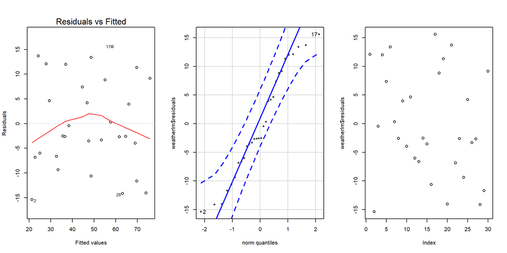

```r
par(mfrow = c(1,3))
plot(weatherlm, which=1)
qqPlot(weatherlm$residuals)
plot(weatherlm$residuals)
```

The data is nice and spread out in the first plot, so we may assume equal variance. The QQ-plot shows the data lies within the bands, so we may assume it is normally distributed. The final plot also indicates independence due to the equally spread out data.

Since the assumptions all check out, we may rely on the regression’s p-value:
$$p = 1.89 * 10^{-10}$$

This is significant, so we can conclude the true regression line has a non-zero slope. This tells us the analysis performed is a valid one.